# ippolito_week3_part2

### DATA620 - Week 3 - Part 2

#### Michael Ippolito

6/15/2022

Here is a dataset that shows a simple 2-node network: the attendance of 18 Southern Women at 14 social events:\ \ Brief Description. Small “musty” datasets like that from this 1941 study have proven very valuable in testing and comparing new network algorithms.\ Dataset.\ Python code to create dataset: https://networkx.github.io/documentation/stable/auto_examples/algorithms/plot_davis_club.html\ \ What can you infer about the relationships between (1) the women, and (2) the social events? \ \ Please provide your code and analysis in an Jupyter notebook stored in your GitHub repository. You may work in a small group on this project. Due end of day Sunday.

### Link to video presentation

[Video](https://github.com/mmippolito/cuny_data620_week3_part2/blob/main/video1844540301.mp4?raw=true)

```
Biadjacency matrix
  (0, 0)	1
  (0, 1)	1
  (0, 2)	1
  (0, 3)	1
  (0, 4)	1
  (0, 5)	1
  (0, 7)	1
  (0, 8)	1
  (1, 0)	1
  (1, 1)	1
  (1, 2)	1
  (1, 4)	1
  (1, 5)	1
  (1, 6)	1
  (1, 7)	1
  (2, 1)	1
  (2, 2)	1
  (2, 3)	1
  (2, 4)	1
  (2, 5)	1
  (2, 6)	1
  (2, 7)	1
  (2, 8)	1
  (3, 0)	1
  (3, 2)	1
  :	:
  (12, 7)	1
  (12, 8)	1
  (12, 9)	1
  (12, 11)	1
  (12, 12)	1
  (12, 13)	1
  (13, 5)	1
  (13, 6)	1
  (13, 8)	1
  (13, 9)	1
  (13, 10)	1
  (13, 11)	1
  (13, 12)	1
```

[output cut: 37 more lines]

```
46 Brenda Rogers
24 Charlotte McDowd
32 Frances Anderson
36 Eleanor Nye
31 Pearl Oglethorpe
40 Ruth DeSand
38 Verne Sanderson
33 Myra Liddel
37 Katherina Rogers
46 Sylvia Avondale
43 Nora Fayette
34 Helen Lloyd
24 Dorothy Murchison
14 Olivia Carleton
14 Flora Price
```

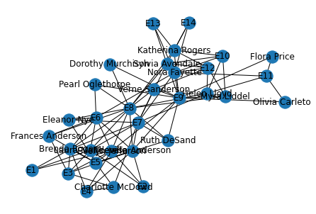

```python
# Code taken from https://networkx.org/documentation/stable/auto_examples/algorithms/plot_davis_club.html
import matplotlib.pyplot as plt
import networkx as nx
import networkx.algorithms.bipartite as bipartite

G = nx.davis_southern_women_graph()
women = G.graph["top"]
clubs = G.graph["bottom"]

print("Biadjacency matrix")
print(bipartite.biadjacency_matrix(G, women, clubs))

# project bipartite graph onto women nodes
W = bipartite.projected_graph(G, women)

print()
print("#Friends, Member")
for w in women:
    print(f"{W.degree(w)} {w}")

# project bipartite graph onto women nodes keeping number of co-occurence
# the degree computed is weighted and counts the total number of shared contacts
W = bipartite.weighted_projected_graph(G, women)
print()
print("#Friend meetings, Member")
for w in women:
    print(f"{W.degree(w, weight='weight')} {w}")

pos = nx.spring_layout(G, seed=648)  # Seed layout for reproducible node positions
nx.draw(G, pos, with_labels=True)
plt.show()
```

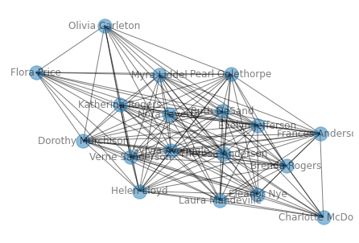

```python
# Import extra libraries
import plotly.express as px
import plotly.io as pio
pio.renderers.default = 'jupyterlab'    # set ploty renderer so graphs show up in HTML output

# Draw projected graph of women
pos = nx.spring_layout(W, seed=648)  # Seed layout for reproducible node positions
nx.draw(W, pos, with_labels=True, alpha=0.5)
plt.show()
```

```
[('Theresa Anderson', 57), ('Evelyn Jefferson', 50), ('Brenda Rogers', 46), ('Sylvia Avondale', 46), ('Laura Mandeville', 45), ('Nora Fayette', 43), ('Ruth DeSand', 40), ('Verne Sanderson', 38), ('Katherina Rogers', 37), ('Eleanor Nye', 36), ('Helen Lloyd', 34), ('Myra Liddel', 33), ('Frances Anders…
```

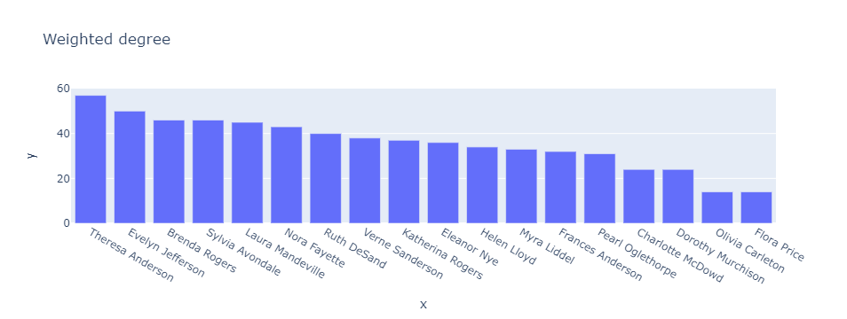

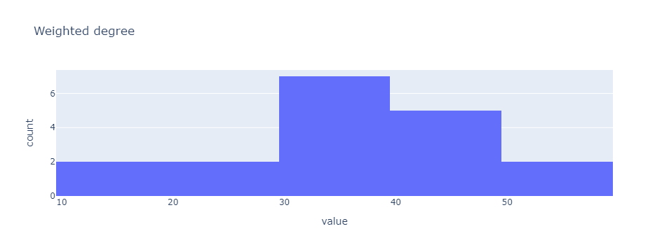

```python
# Degree centrality - women

# Extract women and degrees sorted in descending fashion by degree
srt = sorted(W.degree(weight='weight'), key=lambda tup: tup[1], reverse=True)
w = [w[0] for w in srt]
d = [w[1] for w in srt]

# List the women by weighted degree (the "celebrities") and display vertical bar chart
print(srt)
p2 = px.bar(x=w, y=d, title='Weighted degree')
p2.show()

# Show histogram of weighted degrees
p1 = px.histogram(d, nbins=8, title='Weighted degree')
p1.update_layout(showlegend=False)
p1.show()
```

```
[('Evelyn Jefferson', 1.0), ('Theresa Anderson', 1.0), ('Ruth DeSand', 1.0), ('Verne Sanderson', 1.0), ('Sylvia Avondale', 1.0), ('Nora Fayette', 1.0), ('Helen Lloyd', 1.0), ('Pearl Oglethorpe', 0.9444444444444444), ('Myra Liddel', 0.9444444444444444), ('Katherina Rogers', 0.9444444444444444), ('Dor…
```

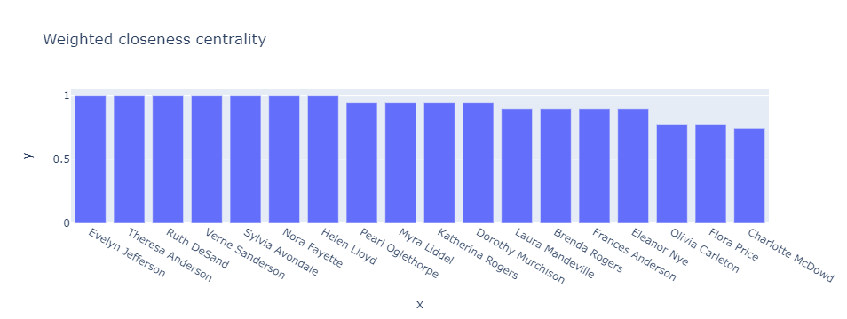

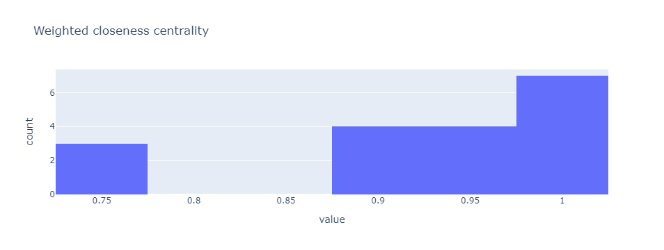

```python
# Closeness centrality - women

# Extract women and closeness centrality sorted in descending fashion by closeness centrality
srt = sorted(nx.closeness_centrality(W).items(), key=lambda item: item[1], reverse=True)
w = [w[0] for w in srt]
cc = [w[1] for w in srt]
print(srt)

# List the women by weighted closeness centrality (the "gossip mongers") and display vertical bar chart
p2 = px.bar(x=w, y=cc, title='Weighted closeness centrality')
p2.show()

# Show histogram of weighted degrees
p1 = px.histogram(cc, nbins=8, title='Weighted closeness centrality')
p1.update_layout(showlegend=False)
p1.show()
```

```
[('Olivia Carleton', 0.13628485485103134), ('Flora Price', 0.13628485485103134), ('Dorothy Murchison', 0.0957700693913929), ('Helen Lloyd', 0.06168870957473897), ('Frances Anderson', 0.057860644257703084), ('Myra Liddel', 0.053729389483065965), ('Katherina Rogers', 0.053729389483065965), ('Verne San…
```

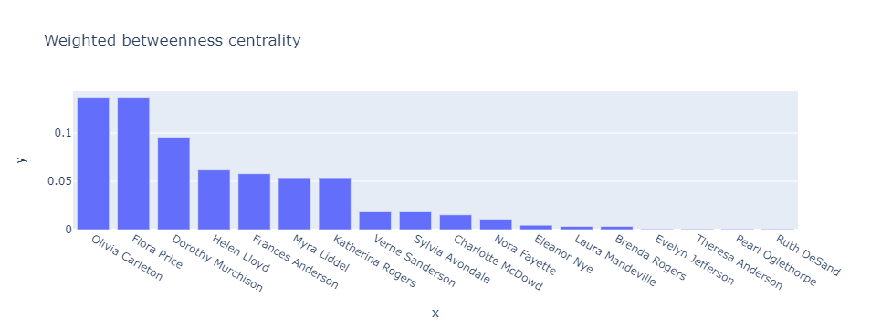

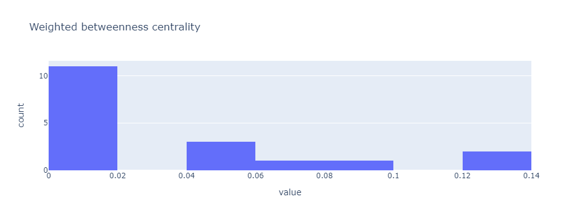

```python
# Betweenness centrality - women

# Extract women and betweenness centrality sorted in descending fashion by betweenness centrality
srt = sorted(nx.betweenness_centrality(W, weight='weight').items(), key=lambda item: item[1], reverse=True)
w = [w[0] for w in srt]
bc = [w[1] for w in srt]
print(srt)

# List the women by weighted closeness centrality (the "gossip mongers") and display vertical bar chart
p2 = px.bar(x=w, y=bc, title='Weighted betweenness centrality')
p2.show()

# Show histogram of weighted degrees
p1 = px.histogram(bc, nbins=8, title='Weighted betweenness centrality')
p1.update_layout(showlegend=False)
p1.show()
```

Olivia Carleton and Flora Price are the standouts for betweenness centrality, indicating that they may form bridges (or bottlenecks) among different groups.

```
[('Theresa Anderson', 0.3535541948691951), ('Evelyn Jefferson', 0.31851926665283264), ('Brenda Rogers', 0.30424398273598313), ('Laura Mandeville', 0.3004069463983671), ('Sylvia Avondale', 0.27287835476049266), ('Nora Fayette', 0.2532742663805232), ('Ruth DeSand', 0.2485104657314361), ('Eleanor Nye',…
```

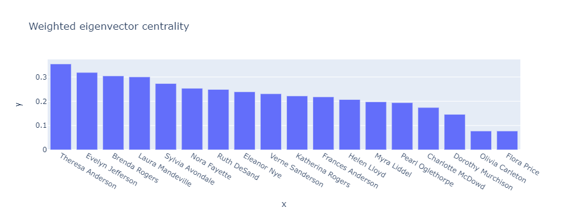

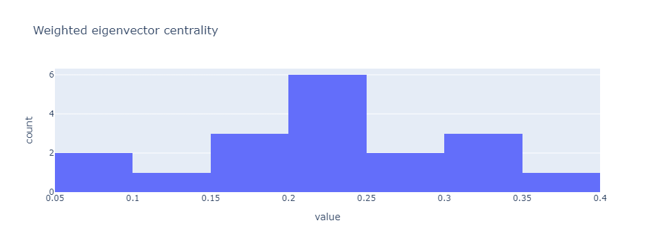

```python
# Eigenvector centrality - women

# Extract women and eigenvector centrality sorted in descending fashion by eigenvector centrality
srt = sorted(nx.eigenvector_centrality(W, weight='weight').items(), key=lambda item: item[1], reverse=True)
w = [w[0] for w in srt]
ec = [w[1] for w in srt]
print(srt)

# List the women by weighted closeness centrality (the "gossip mongers") and display vertical bar chart
p2 = px.bar(x=w, y=ec, title='Weighted eigenvector centrality')
p2.show()

# Show histogram of weighted degrees
p1 = px.histogram(ec, nbins=8, title='Weighted eigenvector centrality')
p1.update_layout(showlegend=False)
p1.show()
```

```
#Members, Club
19 E1
20 E2
32 E3
23 E4
38 E5
41 E6
48 E7
59 E8
46 E9
25 E10
13 E11
28 E12
18 E13
18 E14
```

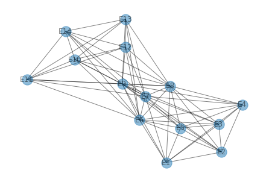

```python
# Until this point we've looked at the network from the perspective of how the women were connected to each other.
# Now look at how the clubs are linked.

# Project bipartite graph onto club nodes
C = bipartite.weighted_projected_graph(G, clubs)

# Print club memberships
print("#Members, Club")
for c in clubs:
    print(f"{C.degree(c, weight='weight')} {c}")

# Draw projected graph of clubs
pos = nx.spring_layout(C, seed=648)  # Seed layout for reproducible node positions
nx.draw(C, pos, with_labels=True, alpha=0.5)
plt.show()
```

```
[('E8', 59), ('E7', 48), ('E9', 46), ('E6', 41), ('E5', 38), ('E3', 32), ('E12', 28), ('E10', 25), ('E4', 23), ('E2', 20), ('E1', 19), ('E13', 18), ('E14', 18), ('E11', 13)]
```

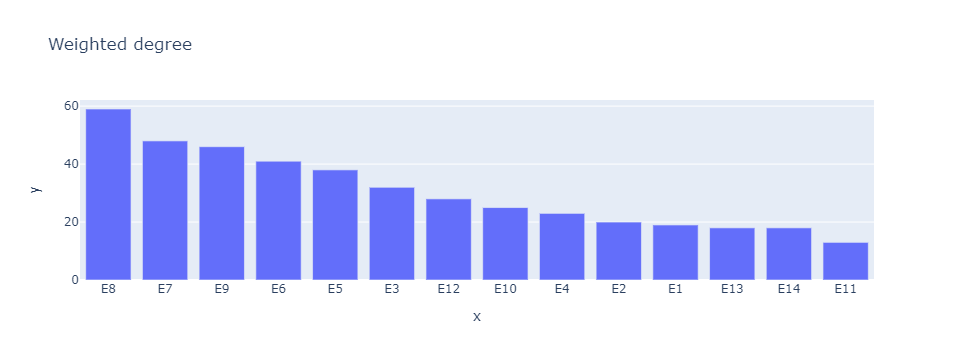

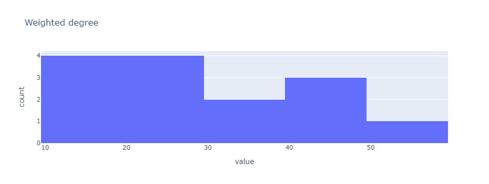

```python
# Degree centrality - clubs

# Extract clubs and degrees sorted in descending fashion by degree
srt = sorted(C.degree(weight='weight'), key=lambda tup: tup[1], reverse=True)
c = [w[0] for w in srt]
d = [w[1] for w in srt]

# List the clubs by weighted degree (the "celebrities") and display vertical bar chart
print(srt)
p2 = px.bar(x=c, y=d, title='Weighted degree')
p2.show()

# Show histogram of weighted degrees
p1 = px.histogram(d, nbins=8, title='Weighted degree')
p1.update_layout(showlegend=False)
p1.show()
```

With a weighted membership of 59, E8 is the most popular club.

```python
# Analyze subcomponents

# Get number of subgraphs - women
print("Number of women's subgraphs:", len([c for c in nx.connected_components(W)]))

# Get number of subgraphs - clubs
print("Number of club subgraphs:", len([c for c in nx.connected_components(C)]))
```

```
Number of women's subgraphs: 1
Number of club subgraphs: 1
```

No disconnected networks exist in either the case of women or of clubs.

```python
# Define function to trim edges based on weight
# Maksim Tsvetovat & Alexander Kouznetsov, Social Network Analysis for Startups, 2011
def trim_edges(g, weight=1):
    g2 = nx.Graph()
    for f, to, edata in g.edges(data=True):
        if edata['weight'] > weight:
            g2.add_edge(f, to, weight=edata['weight'])
    return g2
```

```python
# Find subgraphs
#print(sorted(W.edges(data=True), key=lambda wt: wt[2]['weight'], reverse=True))
for i in range(1, 7):
    print(i)
    WW = trim_edges(W, i)
    print("weight=" + str(i) + ":", len([c for c in nx.connected_components(WW)]), "subgraphs")
```

```
1
weight=1: 1 subgraphs
2
weight=2: 1 subgraphs
3
weight=3: 2 subgraphs
4
weight=4: 2 subgraphs
5
weight=5: 2 subgraphs
6
weight=6: 1 subgraphs
```

The fact that there are at most two subgraphs indicates that the women are all well connected as opposed to disjointed.

```python
# Find cliques
cliques = list(nx.find_cliques(W))
print("There are", len(cliques), "cliques:")
for i, clique in enumerate(cliques):
    print(i, clique)
```

```
There are 3 cliques:
0 ['Theresa Anderson', 'Ruth DeSand', 'Nora Fayette', 'Helen Lloyd', 'Verne Sanderson', 'Sylvia Avondale', 'Evelyn Jefferson', 'Charlotte McDowd', 'Eleanor Nye', 'Frances Anderson', 'Laura Mandeville', 'Brenda Rogers']
1 ['Theresa Anderson', 'Ruth DeSand', 'Nora Fayette', 'Helen Lloyd', 'Verne Sanderson', 'Sylvia Avondale', 'Evelyn Jefferson', 'Katherina Rogers', 'Myra Liddel', 'Dorothy Murchison', 'Pearl Oglethorpe', 'Eleanor Nye', 'Laura Mandeville', 'Frances Anderson', 'Brenda Rogers']
2 ['Theresa Anderson', 'Ruth DeSand', 'Nora Fayette', 'Helen Lloyd', 'Verne Sanderson', 'Sylvia Avondale', 'Evelyn Jefferson', 'Katherina Rogers', 'Myra Liddel', 'Dorothy Murchison', 'Pearl Oglethorpe', 'Flora Price', 'Olivia Carleton']
```